# Gene expression Deconvolution for human PDACA SRT datasets

Jia-Juan Tu

## Import library

```r
#remove(list= ls())
library(ggplot2)
library(ggthemes)
library(scatterpie)
library(cowplot)
library(gridExtra)
library(viridis)
library(ggpubr)
library(rstatix)
library(RColorBrewer)
require(clusterProfiler)
require(org.Hs.eg.db)
require(dplyr)
library(stringr)
library(purrr)
library(stringr)
library(nichenetr)
library(tidyverse)
library(circlize)
library(tibble)
library(parallel)
library(doParallel)
library(glmnet)
```

### Load function

```r
source("./code/STged.R")
source("./code/benchmark.R")
source("./code/Module.R")
```

### load data

```r
datax = readRDS("./realdata/PDAC/PDACA_R_all.RDS")

stged = readRDS("./results/PDAC/major/model.est.rds")
```

## set the color of each cell types

```r
qual_col_pals = brewer.pal.info[brewer.pal.info$category == 'qual',]
col_vector  <-  unlist(mapply(brewer.pal, qual_col_pals$maxcolors,
                              rownames(qual_col_pals)))
```

```r
ctexp  = stged$F_list
beta.type = stged$beta
colnames(beta.type)
```

```
## [1] "Ductal antigen presenting" "Ductal centroacinar"
## [3] "Ductal high hypoxic"       "Ductal terminal"
## [5] "Macrophages"               "Malignant"
## [7] "T cells and NK cells"
```

```r
ind_spot =datax$spot_exp>0

ind = beta.type[,6]>0.05


st_exp_raw = ctexp[[6]]  #*ind_spot


colnames(st_exp_raw) = rownames(beta.type)

rownames(st_exp_raw)=  gsub("(^|[[:space:]])([[:alpha:]])", "\\1\\U\\2",
                            tolower(rownames(st_exp_raw )), perl = TRUE)
colnames(beta.type)
```

```
## [1] "Ductal antigen presenting" "Ductal centroacinar"
## [3] "Ductal high hypoxic"       "Ductal terminal"
## [5] "Macrophages"               "Malignant"
## [7] "T cells and NK cells"
```

```r
st_exp  = st_exp_raw[,ind ]

datax$spot_loc = datax$spot_loc[rownames(beta.type),]
datax$srt_exp = datax$srt_exp[ ,rownames(beta.type)]

spot_loc_raw  = datax$spot_loc
```

## get the estimated data

```r
spot_loc = spot_loc_raw[ind ,]
beta = beta.type[ind ,]

cell_type = colnames(beta)

target  = j = cell_type[6]
target
```

```
## [1] "Malignant"
```

```r
col_df <- data.frame(cell_types = c(cell_type,"Others"),
                     col_vector = c(col_vector[1:length(cell_type)],"gray"))
```

## Spatial distribution of the proportion of malignant cell types

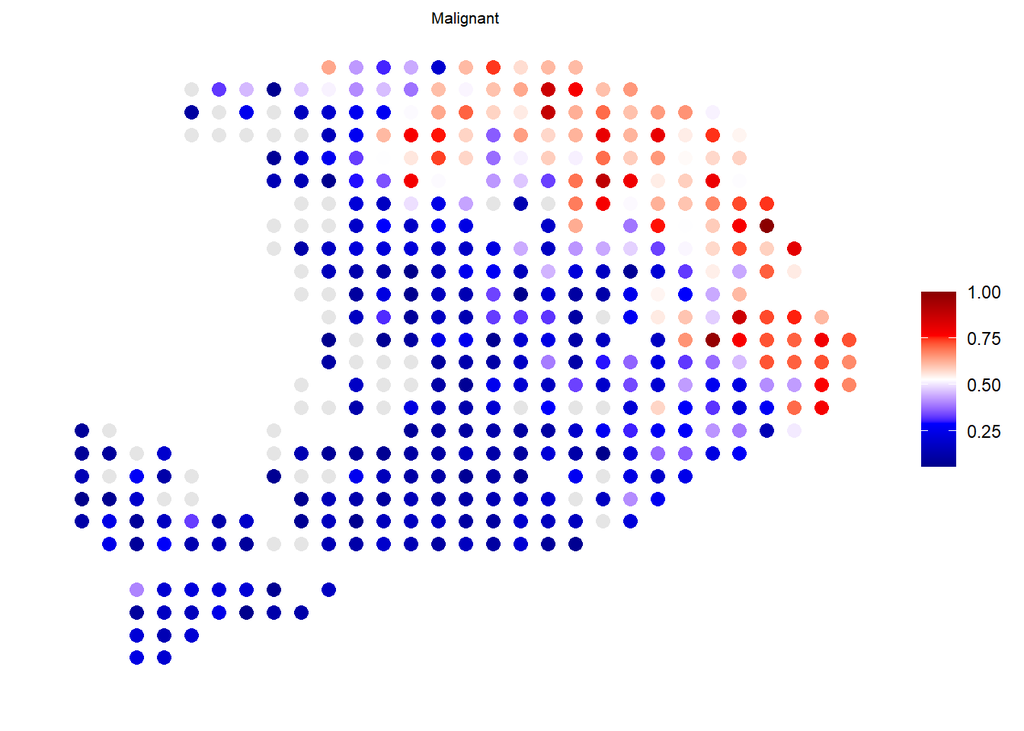

```r
data_weight = data.frame(x = spot_loc_raw$x, y= spot_loc_raw$y,
                         prop  = beta.type[,j]/max(beta.type[,j]))

data_weight$color <- ifelse(data_weight$prop == 0, "gray", NA)


ggplot(data = data_weight, aes(x = x, y = y)) +
  geom_point(aes(color = prop), size = 3, data = subset(data_weight, prop != 0)) +
  geom_point(color = "gray90", size = 3, data = subset(data_weight, prop == 0)) +
  scale_color_gradientn(colours = c("darkblue", "blue", "white", "red", "darkred")) +
  labs(y = "", x = " ", title = as.character(j), color = "", size = "") +
  theme_classic() +
  theme(
    axis.ticks = element_blank(),
    axis.text = element_blank(),
    panel.border = element_blank(),
    axis.line = element_blank(),
    plot.title = element_text(size = 8, hjust = 0.5)
  )
```

# mHVG estimation analysis

## prepare the input

```r
st_exp  = st_exp_raw[,ind ]

dim(st_exp)
```

```
## [1] 9836  378
```

```r
Y_input = t(cleanCounts (st_exp, clean.only =TRUE) )

dim(Y_input)
```

```
## [1]  378 9712
```

```r
dim(beta)
```

```
## [1] 378   7
```

```r
colSums((beta!=0)*1)>(ncol(st_exp)*0.1)
```

```
## Ductal antigen presenting       Ductal centroacinar       Ductal high hypoxic
##                      TRUE                      TRUE                      TRUE
##           Ductal terminal               Macrophages                 Malignant
##                      TRUE                      TRUE                      TRUE
##      T cells and NK cells
##                      TRUE
```

```r
neighbor =  colnames(beta)[colSums((beta!=0)*1)>(ncol(st_exp)*0.1)]

X_input = beta[,neighbor]
X_input = X_input[,-match(target, colnames(X_input))]
neighbor_sec = colnames(X_input)
```

```r
Y_scaled <- scale(Y_input)


file_path <- './results/PDAC/major/mHVG_elastic_est.RDS'

# Check if the file exists
if (!file.exists(file_path)) {
  # If the file doesn't exist, run the following code

  mHAG_est <- mHAG_func(X_scaled = X_input,
                        Y_scaled = Y_scaled,
                        alpha = 0.5,
                        num_cores = 10)

  # Save the result
  saveRDS(mHAG_est, file = file_path)
} else {
  # If the file exists, print a message
  mHAG_est = readRDS('./results/PDAC/major/mHVG_elastic_est.RDS')
}
```

## the number of mHVGs for terget cell types, manigant

```r
mHAG_est_nor = mHAG_est
mHAG_est_nor[abs(mHAG_est_nor)<1e-5]=0
mHVG <- get_non_zero_gene_names(mHAG_est_nor)

length(mHVG)
```

```
## [1] 1423
```

```r
cat("number of mHVGs=",  length(mHVG), "\n")
```

```
## number of mHVGs= 1423
```

```r
coeff = t(mHAG_est_nor[,mHVG])
coeff_ind = coeff > 0
```

### plot dcor for the mHVGs

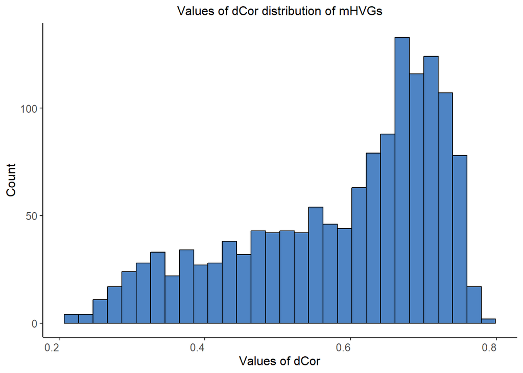

```r
result <- sapply(1:length(mHVG), function(i) {
  energy::dcor(Y_scaled[, mHVG[i]], X_input)
})


dcor.bar = ggplot(data = data.frame(x = result), aes(x = x)) +
    geom_histogram(fill = "#4E84C4",bins = 30, color = "black")+ theme_bw()+
    labs(y = "Count" , x = "Values of dCor",
         title =  "Values of dCor distribution of mHVGs" )+
    theme(
      axis.text.x.bottom = element_text(size = 10,hjust = 1),
      axis.text.y.left = element_text(size = 10),
      axis.title.x = element_text(size = 12, hjust = 0.5),
      axis.title.y = element_text(size = 12),
      plot.title = element_text( size=12,hjust = 0.5),
      panel.grid.major = element_blank(),
      panel.grid.minor = element_blank(),
      panel.border = element_blank(),
      axis.line = element_line(colour = "black"))

print(dcor.bar)
```

```r
ggsave(dcor.bar, file='./results/PDAC/major/dcor.pdf',width = 10, height = 5)
```

## ctHVG

```r
cat("number of mHVGs=",  length(mHVG), "\n")
```

```
## number of mHVGs= 1423
```

```r
cat("number of ctHVGs", "\n")
```

```
## number of ctHVGs
```

```r
apply(abs(coeff)>0,2,sum, na.rm = TRUE)
```

```
## Ductal antigen presenting       Ductal centroacinar       Ductal high hypoxic
##                       579                      1365                       121
##           Ductal terminal               Macrophages      T cells and NK cells
##                       448                       450                       879
```

## PCC score analysis

**NOTE**: PCC score for gene expression levels of malignant cells and cell type proportions on the ctHVGs ## Calculate Joint score

```r
Joinscores = PCC.score(spot_exp = Y_input, coeff = coeff, spot_prop = beta)
```

### plot barplot of joint scores

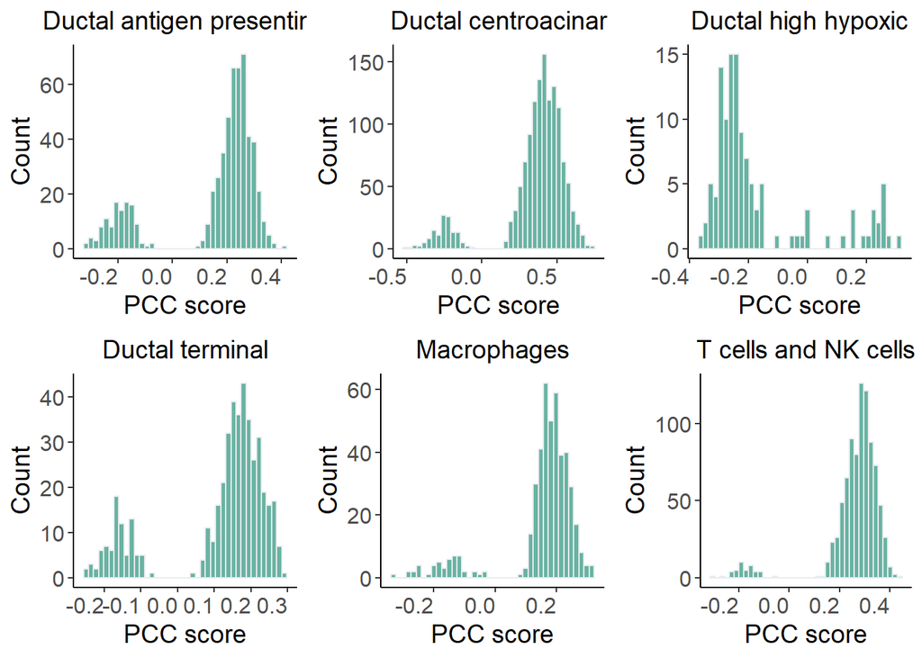

```r
score.barplot = Jointscore.barplot(Score = Joinscores, y.title="Count",
                                   x.title="PCC score",
                                   plot = FALSE, nrow = 1, fill="#69b3a2", color="#e9ecef")

pfig = cowplot::plot_grid(plotlist = score.barplot, nrow = 2)

pfig
```

## The number of ctHVGs for the intersted cell types: Macrophages,T cells

```r
temp = coeff[,5]
Macrophages  = names(temp[temp!=0])
length(Macrophages)
```

```
## [1] 450
```

```r
temp = coeff[,6]
Tcells = names(temp[temp!=0])
length(Tcells)
```

```
## [1] 879
```

```r
# for the macorphage cell
i = 5
colnames(coeff)[i]
```

```
## [1] "Macrophages"
```

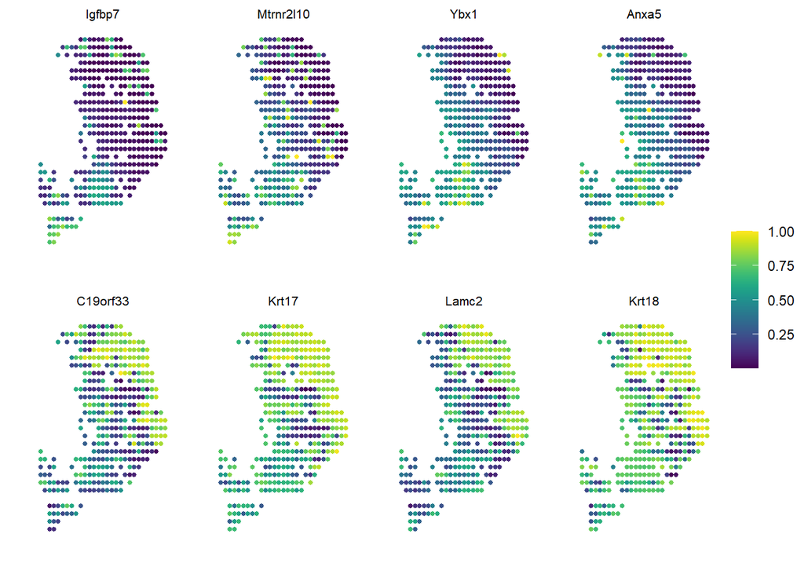

```r
plot1 = pval.srt.dot ( spot_exp = t(Y_input),  spot_prop = beta[,6],
                       spot_loc = spot_loc,
                         coeff =  coeff[, colnames(coeff)[i]], size =1, seck = 4)

psvgpor_macro = ggpubr::ggarrange( plotlist = plot1, nrow = 2, ncol = 4,
                             common.legend = TRUE, legend = "right")
psvgpor_macro
```

```r
# for T cells and NK cells
i = 6
colnames(coeff)[i]
```

```
## [1] "T cells and NK cells"
```

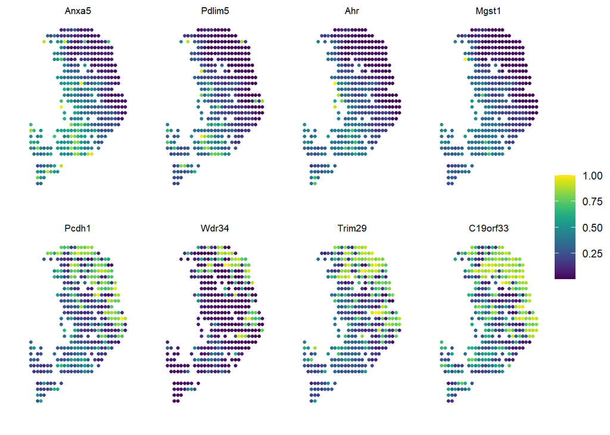

```r
plot2 =  pval.srt.dot ( spot_exp = t(Y_input),  spot_prop = beta[,6],
                       spot_loc = spot_loc,
                         coeff =  coeff[, colnames(coeff)[i]], size =1, seck = 4)

psvgpor_tcell = ggpubr::ggarrange( plotlist = plot2, nrow = 2, ncol = 4,
                             common.legend = TRUE, legend = "right")
psvgpor_tcell
```

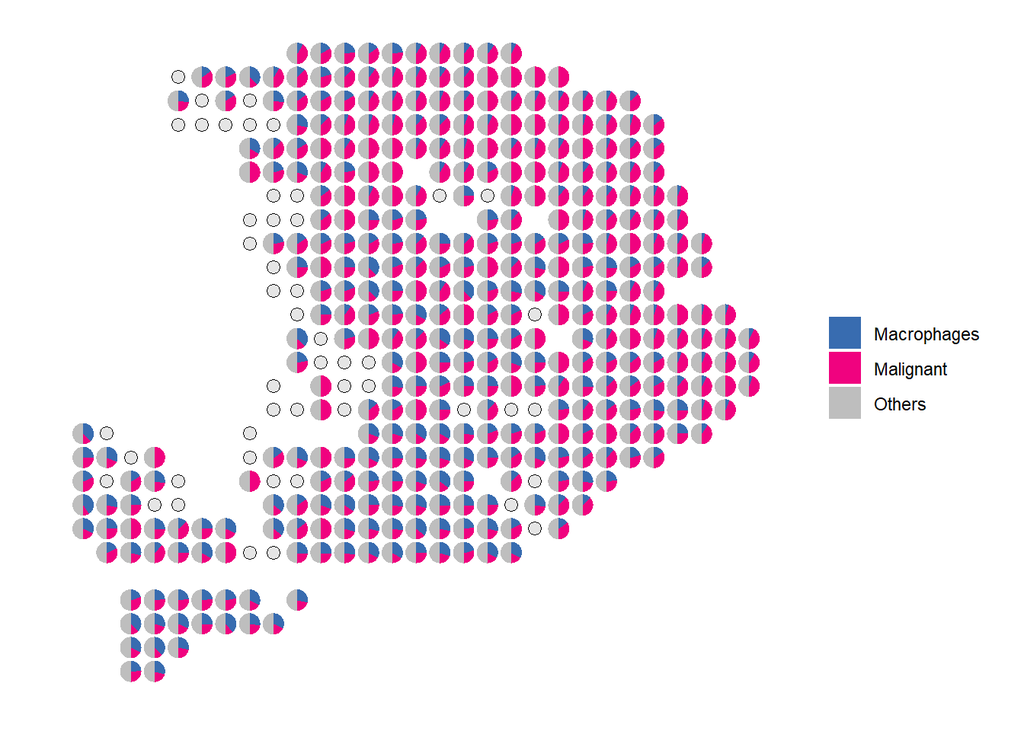

```r
## for the macorphage

proportion = beta.type
keep_spots <- rownames(proportion)[which(proportion[, "Malignant"] > 0)]
sec_type  = c("Macrophages", "Malignant")
test_proportion <- rowSums(proportion[keep_spots, sec_type])

prop_Sec <- cbind(proportion[keep_spots, sec_type], test_proportion)

colnames(prop_Sec) <- c(sec_type, "Others")
rownames(prop_Sec) <- keep_spots

pie_cthvg_macro = plot_scatterpie(spot_loc_raw, prop_Sec, use_color = col_df  ,
                              pie_r = 0.8, circle_r = 0.7, point_size = 4)
pie_cthvg_macro
```

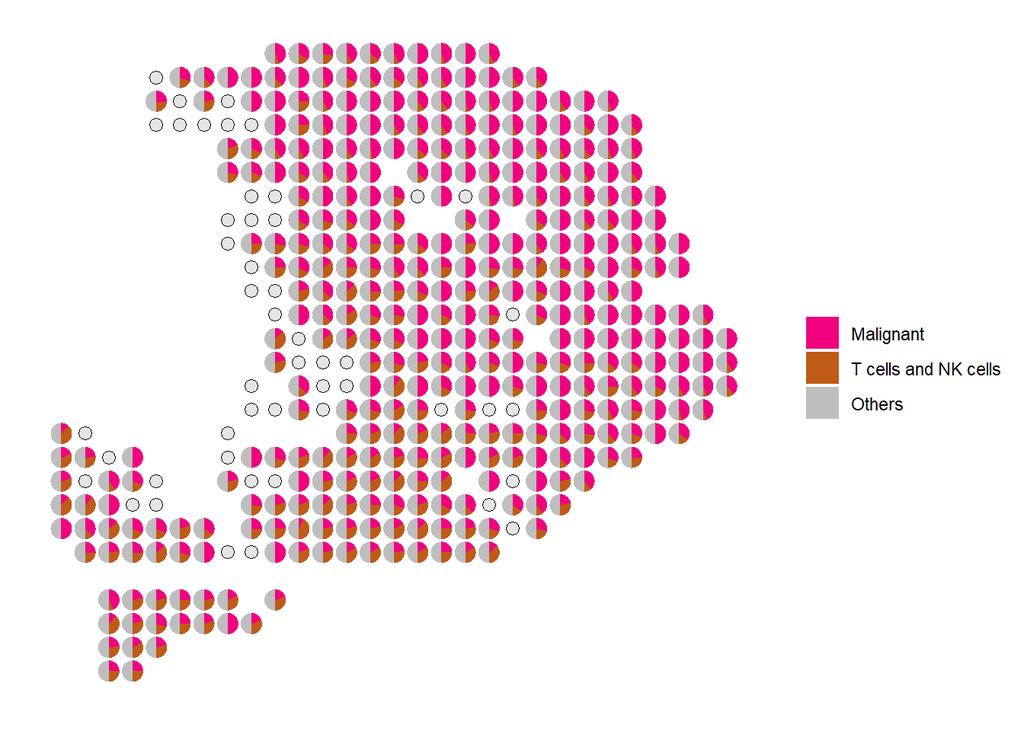

```r
## for the T cells and NK cells
proportion = beta.type
keep_spots <- rownames(proportion)[which(proportion[, "Malignant"] > 0)]
sec_type  = c( "Malignant","T cells and NK cells" )
test_proportion <- rowSums(proportion[keep_spots, sec_type])

prop_Sec <- cbind(proportion[keep_spots, sec_type], test_proportion)

colnames(prop_Sec) <- c(sec_type, "Others")
rownames(prop_Sec) <- keep_spots

pie_cthvg_tcell = plot_scatterpie(spot_loc_raw, prop_Sec, use_color = col_df  ,
                              pie_r = 0.8, circle_r = 0.7, point_size = 4)
pie_cthvg_tcell
```

```r
ctGO_ana11 <-  enrichGO(gene =  toupper(Macrophages),
                        OrgDb = org.Hs.eg.db,
                        keyType = "SYMBOL",
                        ont = "BP",
                        pAdjustMethod = "BH",
                        readable = TRUE)


ctGO_ana21 <- enrichGO(gene =  toupper(Tcells),
                        OrgDb = org.Hs.eg.db,
                        keyType = "SYMBOL",pvalueCutoff = 0.5,
                        ont = "BP",   qvalueCutoff = 0.5,
                        pAdjustMethod = "BH",
                        readable = TRUE)
```

# First plot

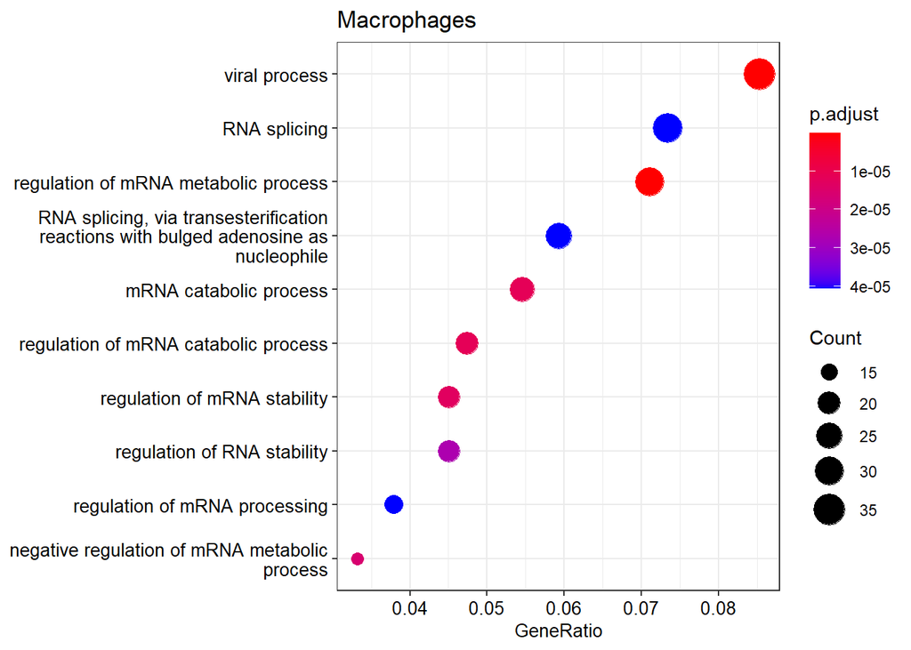

```r
plot1 <- dotplot(ctGO_ana11, showCategory = 10, font.size = 10, label_format = 50) +
  scale_y_discrete(labels = function(y) str_wrap(y, width = 40)) +
  ggtitle("Macrophages")
plot1
```

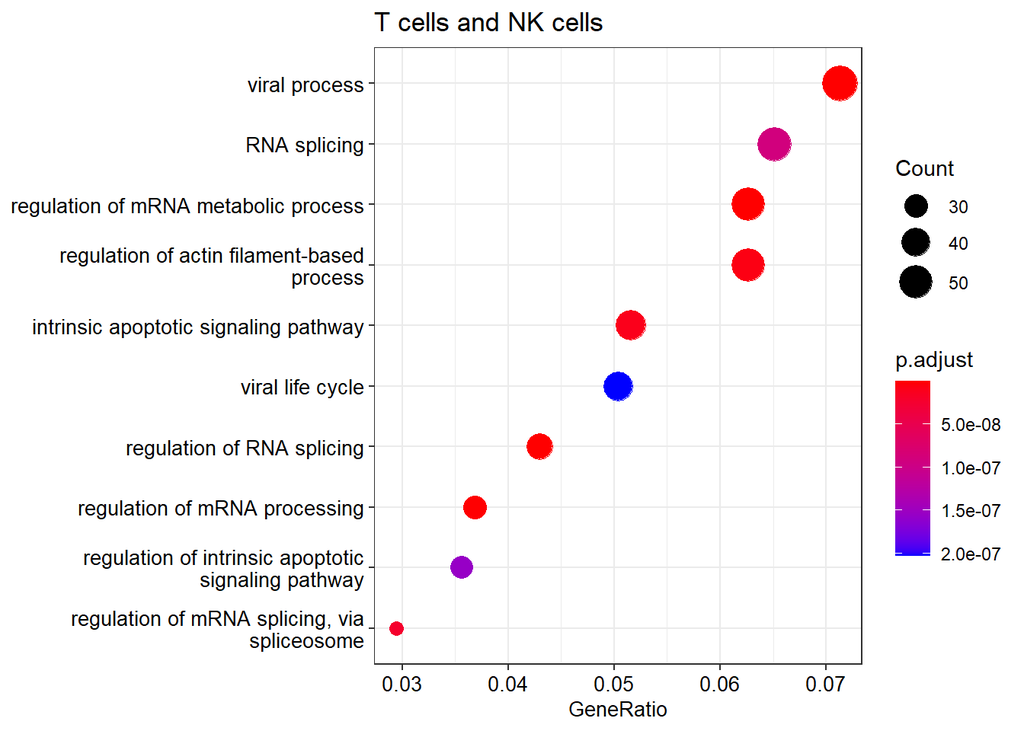

```r
# Second plot
plot2 <- dotplot(ctGO_ana21, showCategory = 10, font.size = 10, label_format = 50) +
  scale_y_discrete(labels = function(y) str_wrap(y, width = 40)) +
  ggtitle("T cells and NK cells")
plot2
```

```r
# Combine the plots using cowplot
combined_plot <- plot_grid(plot1, plot2, labels = c("A", "B"), ncol = 2)

#
```

**Notes** We first define expressed genes in the Macrophages or T cells and NK cells (sender) and malignant cells (receiver). Genes are considered to be expressed within one cell type if their log2-transformed mean TPM (transcript per kilobase million) values are greater than 4, following the same criterion as in the NicheNet tutorial. The mean TPM value for each cell type is calculated based on the cell-type-specific gene expression of spots with the corresponding proportion greater than 0.05 within the focused spots.

```r
lr_network <- readRDS("./realdata/LR_analysis/lr_network_human_21122021.rds")

## ligand-target matrix denoting regulatory potential scores between ligands and targets (ligands in columns)

ligand_target_matrix <-  readRDS("./realdata/LR_analysis/ligand_target_matrix_nsga2r_final.rds")
```

**Notes:** Filtering Expressed Genes

```r
# Define genes and filter spots based on criteria
keep_genes <- rownames(stged$F_list$Malignant)
keep_spots_Macro <- stged$beta[,"Macrophages"] > 0.05
keep_spots_Malignant <- stged$beta[,"Malignant" ] > 0.05
keep_spots_T <- stged$beta[,"T cells and NK cells"] > 0.05

# Identify expressed genes for T cells, macrophages, and malignant cells
expressed_genes_T <- keep_genes[log2(rowMeans(stged$F_list[["T cells and NK cells"]][,keep_spots_T,
                                                                                     drop = FALSE] * 1e6) + 1) >= 4]

expressed_genes_Macro <- keep_genes[log2(rowMeans(stged$F_list[["Macrophages"]][,keep_spots_Macro, drop = FALSE] * 1e6) + 1) >= 4]

expressed_genes_Malignant <- keep_genes[log2(rowMeans(stged$F_list[["Malignant"]][,keep_spots_Malignant, drop = FALSE] * 1e6) + 1) >= 4]
```

**Notes:**The gene set of interest comprises the identified potential interaction-changed genes, encompassing both significantly positively correlated genes and significantly negatively correlated genes.

```r
# Convert gene names and intersect with ligand-target matrix
geneset_ctHVG_macor <- intersect(convert_alias_to_symbols(toupper(Macrophages), "human", verbose = FALSE), colnames(ligand_target_matrix))

geneset_ctHVG_Tcell <- intersect(convert_alias_to_symbols(toupper(Tcells), "human", verbose = FALSE), colnames(ligand_target_matrix))
```

```r
# Convert gene names and intersect with ligand-target matrix
test_genes <- rownames(stged$F_list$Malignant)[rowSums(stged$F_list$Malignant) != 0]

background_expressed_genes <- intersect(convert_alias_to_symbols(toupper(test_genes), "human", verbose = FALSE), rownames(ligand_target_matrix))
```

**Notes:**The potential ligands are defined as ligands expressed in at least one immune cell type and for which at least one putative receptor is expressed in malignant cells.

```r
# Identify ligands and receptors from the ligand-receptor network
ligands <- lr_network %>% pull(from) %>% unique()
expressed_ligands_T <- intersect(ligands, expressed_genes_T)
expressed_ligands_Macro <- intersect(ligands, expressed_genes_Macro)

receptors <- lr_network %>% pull(to) %>% unique()
expressed_receptors <- intersect(receptors, expressed_genes_Malignant)

# Identify potential ligands interacting with receptors
potential_ligands_T <- lr_network %>% filter(from %in% expressed_ligands_T & to %in% expressed_receptors) %>% pull(from) %>% unique()

potential_ligands_Macro <- lr_network %>% filter(from %in% expressed_ligands_Macro & to %in% expressed_receptors) %>% pull(from) %>% unique()
```

**Notes:**We then perform NicheNet’s ligand activity analysis.

```r
# Predict ligand activities for macrophages
ligand_activities_macro <- predict_ligand_activities(
  geneset = geneset_ctHVG_macor,
  background_expressed_genes = background_expressed_genes,
  ligand_target_matrix = ligand_target_matrix,
  potential_ligands = potential_ligands_Macro
)

best_upstream_ligands_macro <- ligand_activities_macro %>% arrange(-aupr_corrected) %>% pull(test_ligand)

# Predict ligand activities for T cells
ligand_activities_Tcell <- predict_ligand_activities(
  geneset = geneset_ctHVG_Tcell,
  background_expressed_genes = background_expressed_genes,
  ligand_target_matrix = ligand_target_matrix,
  potential_ligands = potential_ligands_T
)

best_upstream_ligands_Tcell <- ligand_activities_Tcell %>% arrange(-aupr_corrected) %>% pull(test_ligand)
```

**Notes:**Assign specific ligands to cell types based on expression levels

```r
T_specific_ligands <- intersect(best_upstream_ligands_Tcell, expressed_ligands_T)

Macro_specific_ligands <- intersect(best_upstream_ligands_macro, expressed_ligands_Macro)
```

**Notes:** When inferring target genes of the ligands, we consider the top 100 targets of at least one ligand according to the prior model.

```r
# Infer target genes for T cells
active_ligand_target_links_df_Tcell <- best_upstream_ligands_Tcell %>%
  lapply(get_weighted_ligand_target_links, geneset = geneset_ctHVG_Tcell, ligand_target_matrix = ligand_target_matrix, n = 100) %>%
  bind_rows()

# Infer target genes for macrophages
active_ligand_target_links_df_macro <- best_upstream_ligands_macro %>%
  lapply(get_weighted_ligand_target_links, geneset = geneset_ctHVG_macor, ligand_target_matrix = ligand_target_matrix, n = 100) %>%
  bind_rows()
```

**Notes:** clear data

```r
active_ligand_target_links_df_Tcell_clear = na.omit(active_ligand_target_links_df_Tcell)

active_ligand_target_links_df_macro_clear = na.omit(active_ligand_target_links_df_macro)
```

```r
write.csv(active_ligand_target_links_df_Tcell_clear,file='./results/PDAC/major/lt_Tcell.csv')
write.csv(active_ligand_target_links_df_macro_clear,file='./results/PDAC/major/lt_macro.csv')
```

**Notes:** Create the Bubble Plot

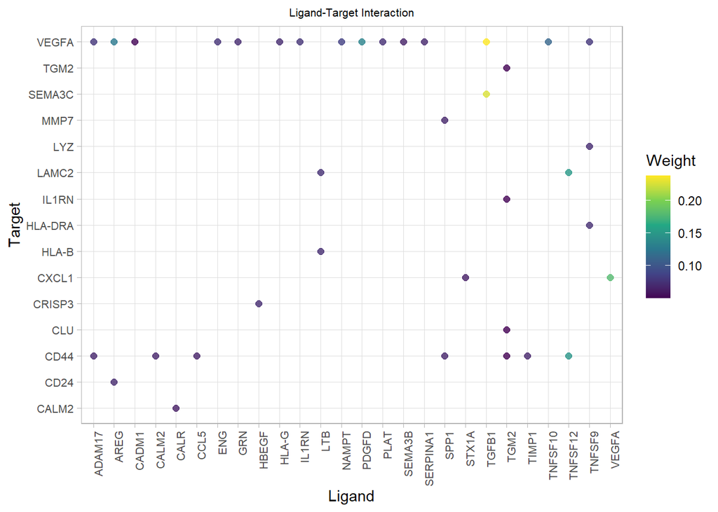

```r
# Convert the matrix to a data frame
df_Tcell <- as.data.frame(active_ligand_target_links_df_Tcell_clear)
colnames(df_Tcell) <- c("Ligand", "Receptor", "Weight")
df_Tcell$Weight <- as.numeric(df_Tcell$Weight)
df_Tcell = df_Tcell[df_Tcell$Weight>0.05,]


# Create the bubble plot
fig_Tcell = ggplot(df_Tcell, aes(x = Ligand, y = Receptor, size = Weight,color =Weight)) +
  geom_point(alpha = 0.8,size = 2) +
  scale_size_continuous(range = c(2, 15)) +
  theme_minimal() +  # Use a minimal theme for clarity
  labs(
    title = "Ligand-Target Interaction",
    x = "Ligand",
    y = "Target",
    size = "Interaction Weight"
  ) +theme_light() +
    theme(
      axis.text.x.bottom = element_text(size = 8,hjust = 1,angle = 90),
      axis.text.y.left = element_text(size = 8),
      #axis.title.x = element_blank(),
     # axis.title.y = element_blank(),
      plot.title = element_text( size=8,hjust = 0.5),
    )+  scale_color_viridis_c()

 fig_Tcell
```

```r
  ggsave(fig_Tcell, file='./results/PDAC/major/lt_TCELL.pdf', width = 10, height = 5)
```

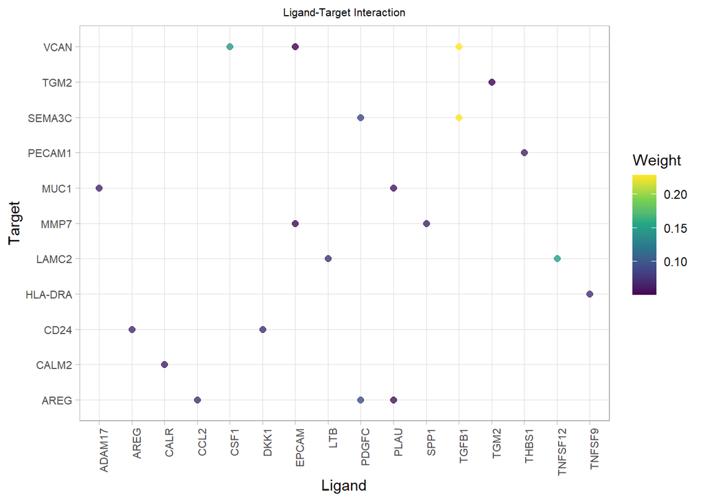

```r
# Convert the matrix to a data frame
df_macro <- as.data.frame(active_ligand_target_links_df_macro_clear)
colnames(df_macro) <- c("Ligand", "Receptor", "Weight")
df_macro$Weight <- as.numeric(df_macro$Weight)
df_macro = df_macro[df_macro$Weight>0.05,]


# Create the bubble plot
fig_macro = ggplot(df_macro, aes(x = Ligand, y = Receptor, size = Weight,color =Weight)) +
  geom_point(alpha = 0.8,size = 2) +
  scale_size_continuous(range = c(2, 15)) +
  theme_minimal() +  # Use a minimal theme for clarity
  labs(
    title = "Ligand-Target Interaction",
    x = "Ligand",
    y = "Target",
    size = "Interaction Weight"
  ) +theme_light() +
    theme(
      axis.text.x.bottom = element_text(size = 8,hjust = 1,angle = 90),
      axis.text.y.left = element_text(size = 8),
      #axis.title.x = element_blank(),
     # axis.title.y = element_blank(),
      plot.title = element_text( size=8,hjust = 0.5),
    )+  scale_color_viridis_c()


 fig_macro
```

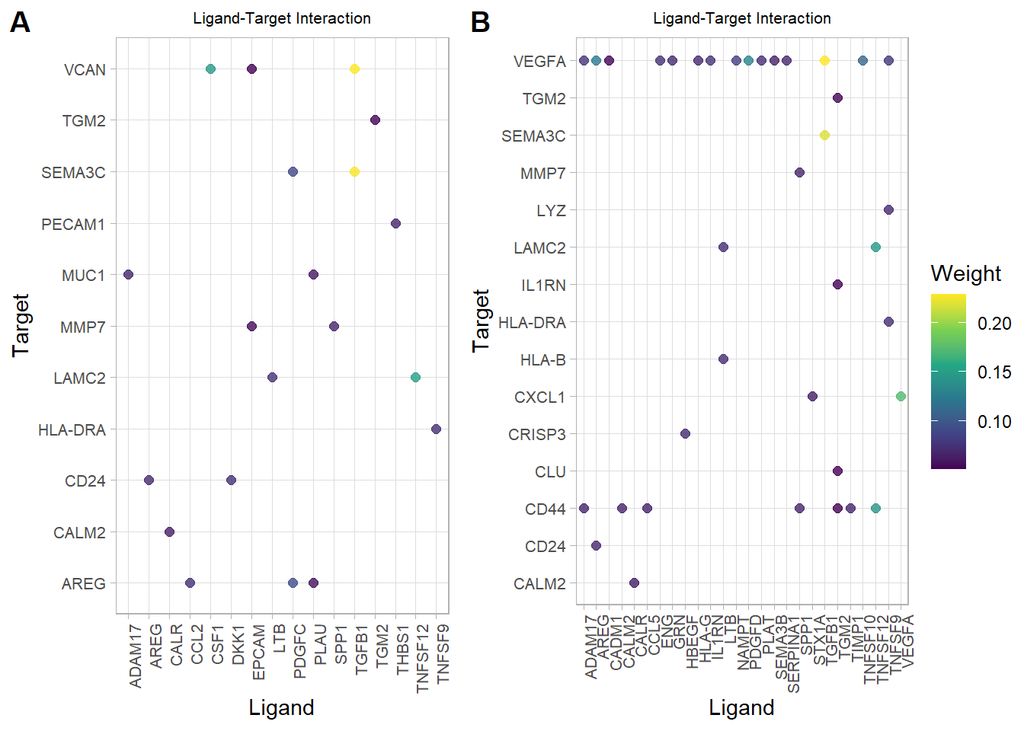

```r
ggsave(fig_macro, file='./results/PDAC/major/lt_macro.pdf', width = 6, height = 5)

 # Combine the plots with common legend and labels
combined_plot <- ggarrange(fig_macro, fig_Tcell,
                           nrow = 1,
                           common.legend = TRUE,
                           labels = c("A", "B"),
                           legend = "right")

# Display the combined plot
print(combined_plot)
```

```r
ggsave(combined_plot, file='./results/PDAC/major/lt_macro_TCELL.pdf', width =10, height = 4)
```

## The BP analysis

```r
ligants_mac = unique(active_ligand_target_links_df_macro_clear$ligand)

ctGO_ana11 <- enrichGO(
  gene = ligants_mac,
  OrgDb = org.Hs.eg.db,
  keyType = "SYMBOL",
  ont = "BP"
)
```

# For the t cell to manigant cells

```r
ligants = unique(active_ligand_target_links_df_Tcell_clear$ligand)

ctGO_ana21 <- enrichGO(
  gene = ligants,
  OrgDb = org.Hs.eg.db,
  keyType = "SYMBOL",
  ont = "BP"
)
```

[figure not shown]

```r
# First plot
plot1 <- dotplot(ctGO_ana11, showCategory = 10, font.size = 10, label_format = 50) +
  scale_y_discrete(labels = function(y) str_wrap(y, width = 40)) +
  ggtitle("Ligands in macrophages")
# Second plot
plot2 <- dotplot(ctGO_ana21, showCategory = 10, font.size = 10, label_format = 50) +
  scale_y_discrete(labels = function(y) str_wrap(y, width = 40)) +
  ggtitle("Ligands in T cells and NK cells")
# Combine the plots using cowplot
combined_plot <- plot_grid(plot1, plot2, labels = c("A", "B"), ncol = 2)

# Display the combined plot
print(combined_plot)
```

```r
ggsave(combined_plot, file='./results/PDAC/major/lt_macro_tnk.pdf', width = 12, height = 5)
```